# Ch04 Confusion and ROC

Bruce Hartman

University of St. Francis

2026-09-11 Revised 2026-10-22T20:13:01

Abstract

We investigate the Receiver Operating Characteristic Curve (ROC) for an unbalanced classification problem.

# Introduction

We present the Receiver Operating Characteristic Curve (ROC) and its relation to the Confusion Matrix. First you should be familiar with the analysis in Classification and Confusion.

# Packages

Loading the standard packages for this course and some others.

```r
library(ISLR2) #package contains the data files, but not this one
library(ROCR) # ROC functions
library(pROC) # obtain function ggroc()
library(mbadtools, quietly=TRUE) # tools for mbad courses
```

See Robin et al., 2011 for more information about `pROC`.

# Data

```r
data(Default)
Default %>% skim
```

```
── Data Summary ────────────────────────
                           Values
Name                       Piped data
Number of rows             10000
Number of columns          4
_______________________
Column type frequency:
  factor                   2
  numeric                  2
________________________
Group variables            None
```

|  | skim_variable | n_missing | complete_rate | ordered | n_unique | top_counts |
| --- | --- | --- | --- | --- | --- | --- |
| 1 | default | 0 | 1 | FALSE | 2 | No: 9667, Yes: 333 |
| 2 | student | 0 | 1 | FALSE | 2 | No: 7056, Yes: 2944 |

|  | skim_variable | n_missing | complete_rate | mean | sd | p0 | p25 | p50 | p75 | p100 | hist |
| --- | --- | --- | --- | --- | --- | --- | --- | --- | --- | --- | --- |
| 1 | balance | 0 | 1 | 835.3749 | 483.715 | 0.0000 | 481.7311 | 823.637 | 1166.308 | 2654.323 | ▆▇▅▁▁ |
| 2 | income | 0 | 1 | 33516.9819 | 13336.640 | 771.9677 | 21340.4629 | 34552.645 | 43807.729 | 73554.233 | ▂▇▇▅▁ |

# Fitting a Logistic Regresssion

Use the Logistic Regression model, with a training dataset and a test dataset. We train the algorithm on one part and test it by making predictions on the other part. Since there are 10000 observations in Default, we will train on the first half and test on the second half. This makes some sense because these are weekly data, and we prefer to train on early data and predict later data.

# Validation Datasets

In classification we should set up a training dataset and a test dataset by partitioning the full dataset. Then we can train the algorithm on one part and test it by making predictions on the other part. Since there are 10000 observations in Default, we will train on the first half and test on the second half. This makes some sense because these are weekly data, and we prefer to train on early data and predict later data.

`tidymodels` provides the best way to do this.

```r
# takes first half of data
split <- initial_time_split(Default, prop = .5)
train_data <- training(split)
test_data  <- testing(split)
dim(train_data)
```

```
[1] 5000    4
```

```r
dim(test_data)
```

```
[1] 5000    4
```

```r
# contrasts for factors
contrasts(Default$default)
```

```
    Yes-No
No    -0.5
Yes    0.5
```

```r
contrasts(Default$student)
```

```
    Yes-No
No    -0.5
Yes    0.5
```

```r
D.train=train_data
D.test=test_data
```

# Logistic Regresssion

We will try Logistic Regression, a common classification technique, and one that is relatively easy to understand.

## Model

Specify the model structure using `tidymodels`. This can be reused each time we run logistic regression.

```r
log_spec <- logistic_reg() %>%
  set_engine("glm") %>%
  set_mode("classification")
```

## Training

Now we can run or ‘train’ logistic regression on the `D.train` part of the dataset. We will try using `balance` and `student` status to predict `default`.

```r
glm.logit <- log_spec %>%
  fit(default ~ balance + student, data = D.train)

glm.logit %>% extract_fit_engine() %>% summary
```

```
Call:
stats::glm(formula = default ~ balance + student, family = stats::binomial,
    data = data)

Coefficients:
                Estimate Std. Error z value Pr(>|z|)
(Intercept)   -1.127e+01  5.470e-01 -20.607  < 2e-16 ***
balance        5.899e-03  3.302e-04  17.868  < 2e-16 ***
studentYes-No -8.402e-01  2.096e-01  -4.009  6.1e-05 ***
---
Signif. codes:  0 ‘***’ 0.001 ‘**’ 0.01 ‘*’ 0.05 ‘.’ 0.1 ‘ ’ 1

(Dispersion parameter for binomial family taken to be 1)

    Null deviance: 1517.14  on 4999  degrees of freedom
Residual deviance:  796.89  on 4997  degrees of freedom
AIC: 802.89

Number of Fisher Scoring iterations: 8
```

```r
glm.logit %>% glance %>% gt_add_significance() %>%
  tab_header(title="glance Overall")
```

glance Overall

| null.deviance | df.null | logLik | AIC | BIC | deviance | df.residual | nobs |
| --- | --- | --- | --- | --- | --- | --- | --- |
| 1,517.1448 | 4,999.0000 | −398.4445 | 802.8891 | 822.4407 | 796.8891 | 4,997.0000 | 5,000.0000 |

```r
glm.logit %>% tidy %>% gt_add_significance() %>%
  tab_header(title="tidy Coefficients")
```

tidy Coefficients

| term | estimate | std.error | statistic | p.value |
| --- | --- | --- | --- | --- |
| (Intercept) | −11.2718 | 0.5470 | −20.6069 | 0.0000 |
| balance | 0.0059 | 0.0003 | 17.8679 | 0.0000 |
| studentYes-No | −0.8402 | 0.2096 | −4.0090 | 0.0001 |

The `summary` and `tidy` show that both drivers are significant.

## Predictions

Next we make predictions for the `D.test` data using the model we developed, using the `predict()` function in R, with the “response” type.

These predictions are probabilities, and we turn them into “No”/“Yes” values by assuming that each is equally likely; the probability of 0.5 is the cutoff. That’s a problem here! They aren’t equally likely.

```r
# prior probability in dataset
prior.train = D.train %>% group_by(default) %>%
  summarize(n_default=n()) %>%
  mutate(fraction = n_default/sum(n_default))
prior.train = prior.train$fraction[prior.train$default=="No"]
prior.train
```

```
[1] 0.965
```

The ‘prior probability’ of default (from the original data) is actually quite small, .035; so the priors are .9650 for No and .035 for Yes.

```r
# probabilities
probs <- predict(glm.logit, new_data = D.test,
                 type = "prob")
preds.class.prior = case_when(
  probs$.pred_Yes > prior.train ~ "Yes",
  .default = "No") %>% factor
preds.class.prior %>% table
```

```
.
  No  Yes
4997    3
```

## Results and Metrics

We compare the results by making a table with the “states of nature” (truth, from the dataset!) in the columns and the predictions in the rows. The columns are the values of default in the test dataset; the rows are the values of `preds`, the predictions, made by the model. Each cell of the table tells us how many observations fell into each category.

```r
t = data.frame(truth=D.test$default,
               estimate = preds.class.prior)
```

We use `conf_mat()` to produce a *confusion matrix*, and a summary to present the different metrics for classification.

```r
cmlog = t %>% conf_mat(truth, estimate)
cmlog
```

```
          Truth
Prediction   No  Yes
       No  4842  155
       Yes    0    3
```

```r
cmlog %>% summary
```

| .metric | .estimator | .estimate |
| --- | --- | --- |
| accuracy | binary | 0.96900000 |
| kap | binary | 0.03613199 |
| sens | binary | 1.00000000 |
| spec | binary | 0.01898734 |
| ppv | binary | 0.96898139 |
| npv | binary | 1.00000000 |
| mcc | binary | 0.13564063 |
| j_index | binary | 0.01898734 |
| bal_accuracy | binary | 0.50949367 |
| detection_prevalence | binary | 0.99940000 |

[output cut: 3 more lines]

# Business Question

The business question here is whether this model can help the bank by predicting defaults.

We have correctly predicted “No” 4842 times, and we correctly predicted “Yes” 3 times. We predicted default=“Yes” 0 times when in reality there was no default. And we predicted “No” 155 times when there was actually a default.

# ROC Curve

An ROC curve can tell us more about the model. It’s a graphical metric.

The ROC is short for ‘receiver operating characteristic’.

The ROC curve is created by plotting the true positive rate (TPR) against the false positive rate (FPR) at various threshold settings. The true-positive rate is also known as **Sensitivity**, **recall** or **probability of detection** in machine learning. The false-positive rate is also known as probability of false alarm, or alpha, and can be calculated as (1 − **Specificity**).

It can also be thought of as a plot of the power as a function of the Type I Error (alpha) of the decision rule (when the performance is calculated from just a sample of the population, it can be thought of as estimators of these quantities). The ROC curve is thus the sensitivity as a function of fall-out.

## `tidymodels` plot

We trained the logit regression above in `glm.logit`, and computed the probabilities in `probs`. Plot the curve for the test data predictions.

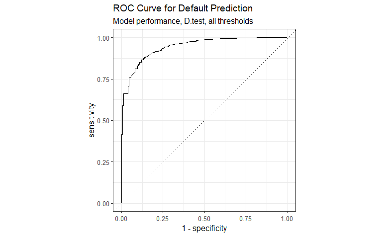

```r
# Combine the true `default` status with the predicted probabilities.
roc_data <- bind_cols(D.test %>% select(default),
                      probs)
# Calculate the ROC curve data and plot it
roc_plot <- roc_data %>%
  roc_curve(truth = default, .pred_No) %>%
  autoplot() +
  labs(title = "ROC Curve for Default Prediction",
       subtitle = "Model performance, D.test, all thresholds")
# make the plot with no frills
roc_plot
```

A fancier version with `ggplot` avoids the simpler `autoplot`.

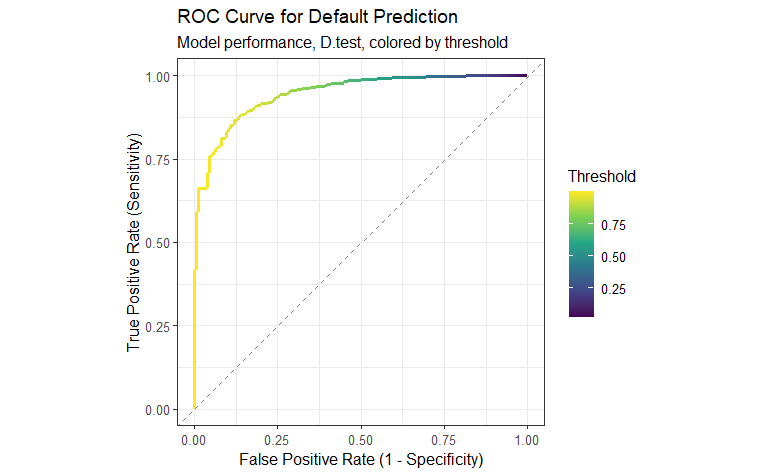

```r
# Calculate the ROC curve data and plot it manually with ggplot2
roc_plot <- roc_data %>%
  roc_curve(truth = default, .pred_No) %>%
  # Map 1-specificity to X, sensitivity to Y, and color by threshold
  ggplot(aes(x = 1 - specificity,
             y = sensitivity,
             color = .threshold)) +
  geom_path(linewidth = 1) +
  geom_abline(lty = 2,
              color = "gray50") + # Adds the diagonal reference line
  coord_equal() + # Keeps the plot square
  scale_color_viridis_c() + # Adds a nice continuous color scale
  labs(
    title = "ROC Curve for Default Prediction",
    subtitle = "Model performance, D.test, colored by threshold",
    x = "False Positive Rate (1 - Specificity)",
    y = "True Positive Rate (Sensitivity)",
    color = "Threshold"
  ) +
  theme_bw()

roc_plot
```